# HW6

164693 박주성

2020 6 2

# 1

$$\rho \ = \ \frac {Cov(X_i, \ X_j)}{\sigma_{x_i}\sigma_{x_j}}$$

여기서 표준 정규화를 고려한다면 $\sigma_{x_i}$와 $\sigma_{x_j}$는 1이 된다. 이에 따라서 $Cov(X_i, \ X_j)$만 고려하면 된다.

$$X_i = (a_{i1}, \ a_{i2}, \ ..., \ a_{im})(F_1, \ F_2, \ ..., \ F_m)' \ + \ e_i= a_i'F \ + \ e_i, \\
X_j = (a_{j1}, \ a_{j2}, \ ..., \ a_{jm})(F_1, \ F_2, \ ..., \ F_m)' \ + \ e_j= a_j'F \ + \ e_j$$

여기서 F들끼리와 e들끼리는 독립이며, F와 e는 서로 독립이다. 이것을 고려한다면,

$$Cov(X_i, \ X_j) \ = \ a_{i1}Cov(F_1, \ F_1)a_{j1} \ + \ a_{i2}Cov(F_2, \ F_2)a_{j2} \ + \ ... \ + a_{im}Cov(F_m,\ F_m)a_{jm}$$

F의 공분산 행렬은 단위 행렬이므로 Cov는 모두 사라지게 된다.

$$\therefore \rho \ = r_{ij} \ = \ a_{i1}a_{j1} \ + \ a_{i1}a_{j1} \ + \ ... \ + \ a_{im}a_{jm}$$

# 2

$$X_i \ = \ a_i'F + e_i \ \Rightarrow \ h_i^2 \ = a_i'a_i \ = a_{i1}^2 \ + \ ... \ + \ a_{im}^2 \\
if \quad T' \ = T^{-1}, \quad X_i \ = a_i'IF \ + \ e_i \ = \ (a_i'T)(T'F) \ + \ e_i = (a_i^*)'F^* \ + \ e_i \\
then \quad h_i = (a^*)'a^* \ = \ (a_i'T)(T'a_i) \ = a_i'a_i \ = \ a_{i1}^2 \ + \ ... \ + \ a_{im}^2$$

$\therefore$ 직교변환 후의 $h_i$(공통인자에 의해서 설명되는 부분)의 변화는 없다.

# 3

### 3.1

$$-0.43 \ \fallingdotseq \sqrt{3.111} \cdot (-0.246) \\
0.58 \ \fallingdotseq \sqrt{1.809} \cdot 0.432 \\
-0.61 \ \fallingdotseq \sqrt{1.495} \cdot (-0.503) \\
0.06 \ \fallingdotseq \sqrt{1.063} \cdot 0.058$$

### 3.2

$$(-0.43)^2 + (0.58)^2 + (-0.61)^2 + (0.06)^2 \ \fallingdotseq \ 0.91$$

# 4

```r
data <- read.csv("table6_7.csv")
data_pca <- prcomp(data[, -c(1, 11)], scale = TRUE)
summary(data_pca)
```

```
## Importance of components:
##                           PC1    PC2    PC3    PC4     PC5     PC6     PC7
## Standard deviation     2.0237 1.2747 1.0418 0.9513 0.65325 0.58902 0.51916
## Proportion of Variance 0.4551 0.1805 0.1206 0.1006 0.04742 0.03855 0.02995
## Cumulative Proportion  0.4551 0.6356 0.7562 0.8568 0.90417 0.94272 0.97266
##                            PC8     PC9
## Standard deviation     0.36677 0.33391
## Proportion of Variance 0.01495 0.01239
## Cumulative Proportion  0.98761 1.00000
```

eigen value가 1보다 큰 것이 3개 이므로 3개의 PC를 사용한다. total은 사용하지 않는다.

```r
# eigen_values and PC
ev <- data_pca$sdev^2
cbind(ev, t(data_pca$rotation))[1:3,]
```

```
##           ev    Red.meat White.meat        Eggs       Milk       Fish
## PC1 4.095537 -0.31066932 -0.3159279 -0.42059296 -0.3788776 -0.1341071
## PC2 1.624903 -0.06957085 -0.2145720 -0.09986721 -0.1686796  0.6516152
## PC3 1.085324 -0.35546338  0.6284199  0.08050675 -0.4041444 -0.2997139
##         Cereals Starchy.foods Pulses..nuts..and.oilseeds Fruit.and.vegetables
## PC1  0.42982911    -0.2959618                  0.4218085            0.1223681
## PC2 -0.25366332     0.3888849                  0.1293293            0.5037733
## PC3  0.06815673     0.2808551                 -0.1403007            0.3404153
```

```r
library(psych)
fit.pc <- principal(data[, -c(1, 11)], nfactors = 3, rotate = "varimax")
round(fit.pc$values, 3)[1:3]
```

```
## [1] 4.096 1.625 1.085
```

```r
-fit.pc$loadings #부호가 반대로 나오는 것을 고려
```

```
##
## Loadings:
##                            RC1    RC3    RC2
## Red.meat                   -0.695 -0.160 -0.176
## White.meat                        -0.944  0.121
## Eggs                       -0.552 -0.647 -0.158
## Milk                       -0.863 -0.233 -0.111
## Fish                       -0.115  0.167 -0.906
## Cereals                     0.519  0.481  0.604
## Starchy.foods                     -0.542 -0.628
## Pulses..nuts..and.oilseeds  0.524  0.699  0.116
## Fruit.and.vegetables        0.614        -0.471
##
##                  RC1   RC3   RC2
## SS loadings    2.476 2.432 1.898
## Proportion Var 0.275 0.270 0.211
## Cumulative Var 0.275 0.545 0.756
```

factor1은 Red.meat, Eggs, milk에서 큰 음수값을, Creals, 견과류, 과일채소류에서 큰 양수의 값을 가졌다. 이를 보아서 육식보다는 주로  
땅에서 자라는 것을 먹는 것으로 단백질을 보충한다는 것을 의미한다고 생각할 수 있다.

factor2는 fish와 starchy.foods, 과일채소류에서 큰 음수값을 가졌고, Cereals에서 큰 양수값을 가졌다. 이를 보아서 생선이나 녹말,  
과일채소류 대신 주로 시리얼만으로 단백질을 보충한다는 것을 의미한다고 생각할 수 있다.

factor3는 white.meat에서 매우 큰 음수값을 가졌으며, eggs, starchy.food에서 큰 음수값을 가졌다. 그리고 시리얼과  
견과류에서 높은 양수의 값을 가졌다. 이를 보아서 조류는 전혀 먹지 않으며, 달걀이나 녹말 대신 시리얼과 견과류에 의존해서  
단백질을 보충한다는 것을 의미한다고 생각할 수 있다.

```r
scores <- -fit.pc$scores # 부호가 반대로 나오는 것을 고려
rownames(scores) <- data$Country
# scores
```

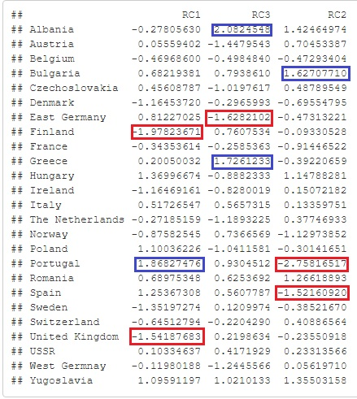

$\pm1.5$ 밖에 있는 지점을 표시했다.

- factor1

factor1에서는 핀란드와 영국이 음수값을 가졌으며, 포르투갈은 양수값을 가졌다.  
핀란드나 영국에서는 주로 육식을 통해서, 포르투갈은 땅에서 자라는 작물을 통해서 단백질을 보충했다는 것이다.  
아마 지리학적으로 영국과 핀란드는 포르투갈에 비해서 위도가 비교적 높은 나라이다.이러한 원인에 의해서 결과가 이렇게  
되었을 것이라 생각한다.

- factor2

factor2에서는 불가리아에서는 양수값, 포르투갈과 스페인에서는 음수값을 가졌다. 이렇게 된 이유도 지리적 위치에 근거한다고 생각한다.  
스페인과 포르투갈은 이베리아 반도에 위치하고 있어서 비교적 바다에 접근이 매우 쉽기에 생선으로 단백질 보충이 쉬울 것이다.  
이에 따라서 스페인과 포르투갈은 factor에서 음수의 값을 가지고 있다. 물론 불가리아도 바다에 인접해 있긴하지만 거의 내해에 가까운  
곳을 근접하기에 어류로 단백질 보충하기엔 어려움이 있을 수 있다. 이러한 원인에 의해서 결과가 이렇게 되었을 것이라 생각한다.

- factor3

factor3에서는 알바니아와 그리스는 양수값을 동독은 음수값을 가졌다. 알바니아와 그리스는 남유럽이고, 동독은 중부유럽에 속한다.  
남쪽에 위치한 알바니아와 그리스는 땅에서 자라는 작물로도 충분히 단백질을 보충할 수 있기에 다른 것을 별로 안먹은 것으로 보이고,  
동독은 조류와 관련된 음식을 많이 먹었을 것이라는 것을 데이터를 통해서 판단할 수 있다. 독일의 통일이 1990년에 일어났는데,  
그 전까지는 동독은 소련이 영향을 미쳤었다. 아마도 소련은 추운 곳이기에 곡물보다는 육식이 발달되어 있을 것이라 생각한다.  
보급에 있어서 동독에 영향을 미쳤기에 이러한 결과가 나왔을 것이라 추측한다.